# Bayesian Observers Performing the Plinko task

P.G.L Porta Mana & A.L.S Filipowicz

## 0) Motivations

The following data was used in “Filipowicz et al., 2016 Rejecting outliers: Surprising Changes Do Not Always Improve Belief Updating, *Decision*”

Participants performed a Plinko experiment in which they were exposed to ball drops sampled from one distribution (either a wide or a narrow distribution) for 100 trials, then switch to 100 ball drops from a second distribution that either changed in mean, holding variance constant, or changing in variance while holding mean constant.

The main results from this experiment were that participants first exposed to a wide gaussian distribution then switched to a narrow distribution with the same mean had difficulty adapting their estimates to reflect the smaller variance. Conversely, participants first exposed to a narrow distribution, then switched to a wide distribution also showed some difficulty updating, treating highly surprising events as outliers.

Missing from this experiment is a sense of how a baysian observer would treat these types of switches given the evidence the participants observed. Does a bayesian observer behave in a similar way to our participants? Or do these participant responses reflect some psychological bias?

There are at least two first order interesting analyses that can be performed on this data.

- 1. How would a bayesian oberver treat these different switches?
- 2. If we start with the participant priors (those provided by each individual participant), how would this influence the bayesian optimal observer?

There are likely more questions, buit these seem like a good start.

## 1) Load data

The code below imports the data from all of subjects that participated in the experiment above and coverts it into a data frame. The columns are as follows:

1. Participant: Participant identifier
2. Condition: Numerical identifier for the switch condition (1 = Wide-Wide mean shift, 2 = Wide-Narrow variance shift, 3 = Narrow-Narrow mean shift, 4 = Narrow-Wide variance shift)
3. Trial: Trial number
4. Distribution.Number: Order in which the current distribution has appeared (1st, 2nd, 3rd 4th)
5. Ball.Position: slot in which the ball fell on the current trial
6. Slot.Number: Slot identifier
7. Participant.Slot.Estimate: Normalized bar height for each slot (normalized participant histograms)
8. Comp.Ball.Drop: Identifier for the slot in which the ball fell on that trial
9. Participant.Mean: Mean of the participant’s distribution (i.e., calculated as the expected value)
10. Participant.SD: Standard deviation of the participant’s distribution
11. Bar.RT: Time taken (in seconds) to adjust bars on each trial (from the time the ball finished droping from the previous trial, until the participant initiated the next ball drop on the current trial)

Note that in total, participants were exposed to 400 trials each, but many subjects did not complete all 400 trials (each was exposed to one mean switch and one variance switch). For the paper above, I only used the first 200 trials of data as these were consistent accross subjects (although you’re welcome to use all of the data if you wish)

```r
setwd('/Users/alsfilip/Dropbox/UW/Luca/PlinkoUpdatingData/')
dpath = "./Plinko_Updating_data/"
fs = dir(path = dpath,pattern = "barData")
d <- read.csv(paste0(dpath,fs[1]))
for (f in fs[2:40]) {
dprime <- read.csv(paste0(dpath, f))
d <- rbind(d,dprime)
rm(dprime)
}
d <- d[,1:(ncol(d)-2)]
```

Below I;m adding some identifiers to make things a little clearer:

SwitchType: More intuitive label for all of the different switch conditions (again, only considering the first 200 trials) Distribution: Which distribution participants were exposed to (W1 is a wide distribution, N1 is a narrow distribution with the same mean as W1, W2 is a wide distribution with the same variance but different mean than W1, and N2 is a narrow distribution with the same variance but different mean from N1)

```r
# Add labels for each distribution
d$SwitchType[d$Condition == 1] = 'W-W' #Wide to wide switch
d$SwitchType[d$Condition == 2] = 'W-N' #Wide to wide switch
d$SwitchType[d$Condition == 3] = 'N-N' #Wide to wide switch
d$SwitchType[d$Condition == 4] = 'N-W' #Wide to wide switch

# Add identifiers for each distribution
d$Distribution[(d$Condition == 1 & d$Distribution.Number == 1)] = "W1"
d$Distribution[d$Condition == 2 & d$Distribution.Number == 1] = "W1"
d$Distribution[d$Condition == 4 & d$Distribution.Number == 2] = "W1"

d$Distribution[(d$Condition == 2 & d$Distribution.Number == 2)] = "N1"
d$Distribution[d$Condition == 3 & d$Distribution.Number == 1] = "N1"
d$Distribution[d$Condition == 4 & d$Distribution.Number == 1] = "N1"

d$Distribution[(d$Condition == 1 & d$Distribution.Number == 2)] = "W2"
d$Distribution[d$Condition == 3 & d$Distribution.Number == 2] = "N2"
```

Here’s a plot of the ball drops for the different conditions (y axis are the slots, and x axis are the trials). The dashed vertical line indicates the moments when the distribution switched.

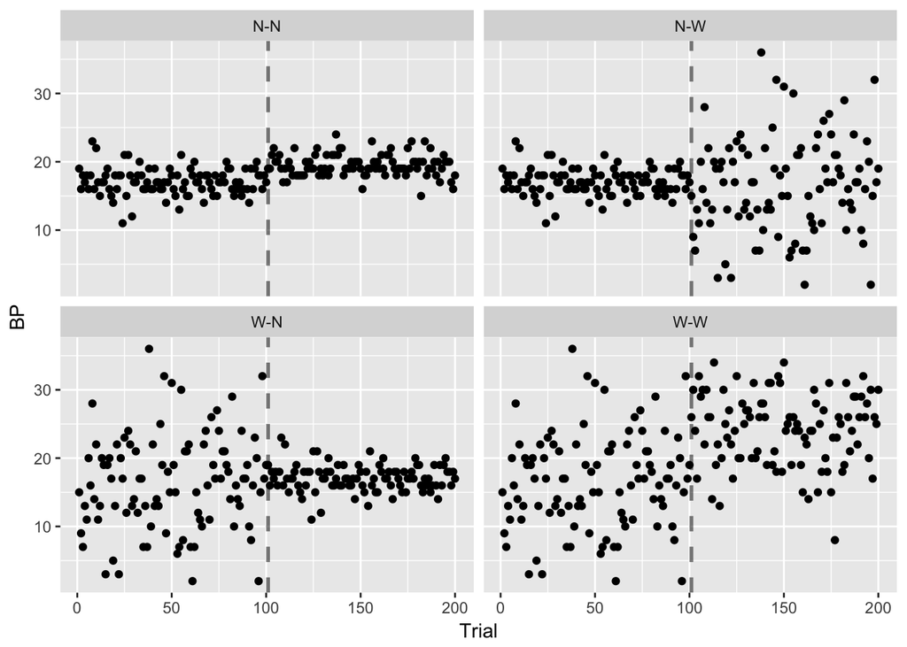

```r
library(plyr)
library(ggplot2)
bds = ddply(d, .(SwitchType,Trial),summarize,BP = mean(Ball.Position))

ds = ddply(d, .(Distribution.Number,Trial),summarize, BP = mean(Ball.Position))


ggplot(subset(bds,Trial < 201),aes(Trial,BP))+
  geom_point()+
  geom_vline(xintercept = 101,size=1, linetype = 'dashed',alpha=.5)+
  facet_wrap(~SwitchType)
```

## 2) Two distribution switching regimes

In the plinkinetti pdf behavior from two robots are presented: one which makes continuous estimates from the start of the task to the end of the task, and one robot that get re-initialized at the start of the second distribution using the posterior belief of the first robot. The main finding is that the second robot adapts much more quickly to the the change in distribution, whereas the first robot has a sort of belief “stickiness”, taking much longer to update.

There is data from the plinko task that almost simulates these scenarios. In the experiment, participants were exposed to four different distributions of 100 ball drops. The distributions were a wide gaussian, a narrow gaussian with a diffrent mean, and bimodal distribution (mix of two gaussians with different means), and a positively skewed distribution.

Participants were exposed to these distributions in two regimes: 1) A continuous condition where, like in the experiment above, participants were switched from distribution to distribution without any explicit indications that the environment had switched, and 2) Break condition, where at the end of each distribution they were shown an accuracy score, then asked to give a new “prior” before starting the next distribution. Note that in neither case were participants told anything about the nature of the distributions they were attempting to estimate, or that any part of the environment would switch.

Here are plots of the empirical ball distributions participants observed

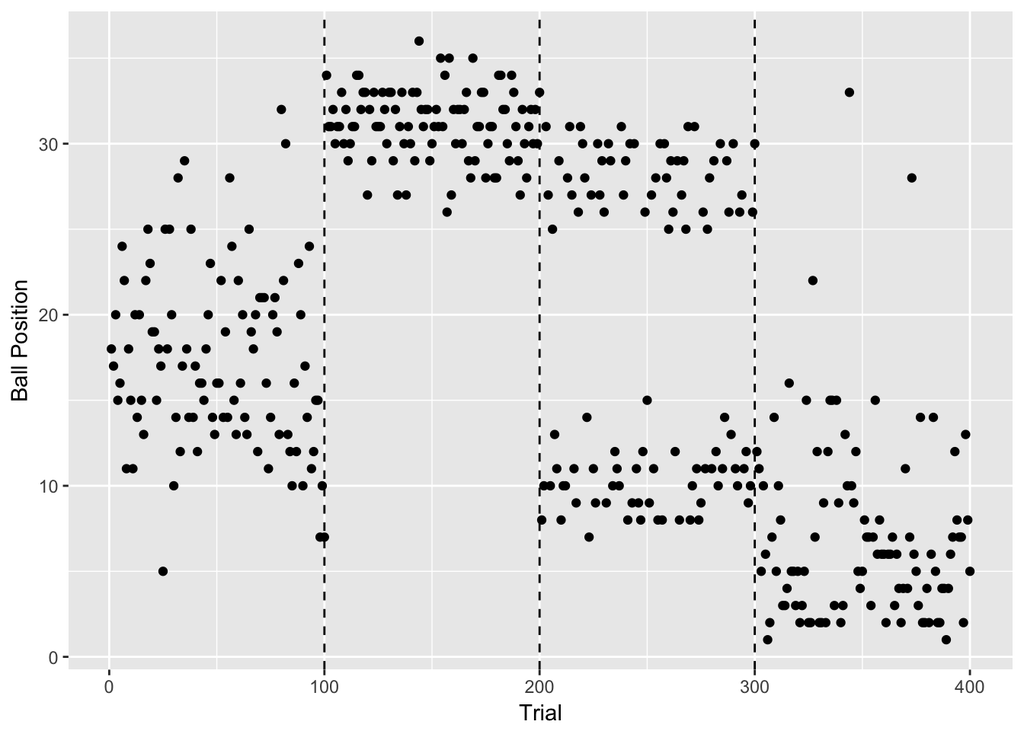

```r
ggplot(dists,aes(Trial,bp))+
  geom_point()+
  geom_vline(xintercept=c(100,200,300),linetype=2)+
  ylab('Ball Position')
```

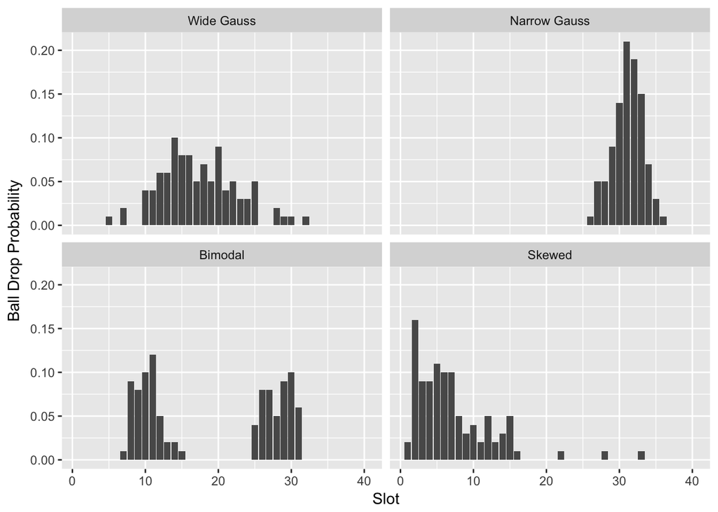

```r
# Get probability mass functions
wide_d = sapply(1:40,function(x) sum(wide==x)/length(wide))
narrow_d = sapply(1:40,function(x) sum(narrow==x)/length(narrow))
bimodal_d = sapply(1:40,function(x) sum(bimodal==x)/length(bimodal))
skewed_d = sapply(1:40,function(x) sum(skewed==x)/length(skewed))

dense_df = data.frame(Slot = rep(1:40,4),
                      Distribution=c(rep("Wide Gauss",40),rep("Narrow Gauss",40),rep("Bimodal",40),rep("Skewed",40)),
                      Probability = c(wide_d,narrow_d,bimodal_d,skewed_d))

ggplot(dense_df,aes(Slot,Probability))+
  geom_bar(stat='identity')+
  ylab('Ball Drop Probability')+
  facet_wrap(~factor(Distribution,levels=c("Wide Gauss","Narrow Gauss","Bimodal","Skewed")))
```

Here is participant accuracy in each of the separate conditions (break and continuous). Accuracy here is defined as the difference in cosine angle between a participant’s distribution on each trial vs the full empirical distribution that they are estimating (this is probably unfair, given that on early trials they have not observed all ball drops of the empirical distribution, but we’ll use this for now).

You can see that participants in the break condition are updating much better to the new distributions. While maybe unsurprising, this is clearly an example where participants are down-weighting previous evidence and restarting their inference processes. This is similar to the second robot in the plinkinetti notes. By contrast, participants in the continuous condition are treating the environment as one continuous inference, similar to the first robot (as can be seen in the second plot, participant estimates in the continuous condition are heavily influenced by previous distributions).

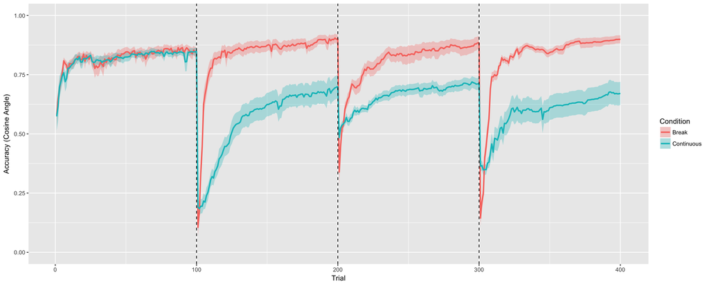

```r
#Now plot participant accuracy as a function of the current environment distribution - I'll use cosine angle here
acc = function(bd,pd){
  return(sum(bd*pd)/(sqrt(sum(bd*bd))*sqrt(sum(pd*pd))))
}

for(s in 1:40){
  d1$DistProb[d1$Slot.Number == s & d1$Distribution.Number == 1] = wide_d[s]
  d1$DistProb[d1$Slot.Number == s & d1$Distribution.Number == 2] = narrow_d[s]
  d1$DistProb[d1$Slot.Number == s & d1$Distribution.Number == 3] = bimodal_d[s]
  d1$DistProb[d1$Slot.Number == s & d1$Distribution.Number == 4] = skewed_d[s]

  d2$DistProb[d2$Slot.Number == s & d2$Distribution.Number == 1] = wide_d[s]
  d2$DistProb[d2$Slot.Number == s & d2$Distribution.Number == 2] = narrow_d[s]
  d2$DistProb[d2$Slot.Number == s & d2$Distribution.Number == 3] = bimodal_d[s]
  d2$DistProb[d2$Slot.Number == s & d2$Distribution.Number == 4] = skewed_d[s]
}

pacc1 = ddply(d1,.(SubID,Condition,Trial),summarize,Acc = acc(DistProb,Participant.Slot.Estimate),BP = mean(Ball.Position))
pacc2 = ddply(d2,.(SubID,Condition,Trial),summarize,Acc = acc(DistProb,Participant.Slot.Estimate),BP = mean(Ball.Position))
pacc = rbind(pacc1,pacc2)

pacc.m = ddply(pacc,.(Condition,Trial),summarize,acc = mean(Acc),mse = mean_se(Acc)[[2]],pse = mean_se(Acc)[[3]])

ggplot(pacc.m,aes(Trial,acc,group=Condition))+
  geom_ribbon(aes(x=Trial,ymin=mse,ymax=pse,fill=Condition),alpha=.3)+
  geom_line(aes(color=Condition),size=1)+
  geom_vline(xintercept=c(100,200,300),linetype=2)+
  ylab('Accuracy (Cosine Angle)')+
  ylim(c(0,1))
```

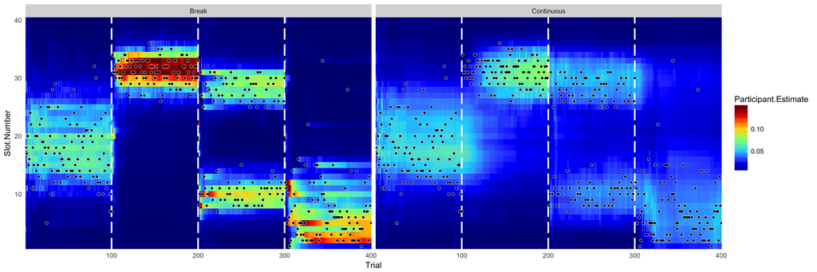

```r
d_all = rbind(d1,d2)
d_all.m = ddply(d_all,.(Condition,Trial,Slot.Number),summarize,Participant.Estimate=mean(Participant.Slot.Estimate))
d_all.m$Participant.Estimate[d_all.m$Participant.Estimate > .15] = .15

jet.colours <- colorRampPalette(c("#00007F", "blue", "#007FFF", "cyan", "#7FFF7F", "yellow", "#FF7F00", "red", "#7F0000"))

ggplot()+
  geom_tile(data=d_all.m,aes(Trial,Slot.Number,fill=Participant.Estimate))+
  scale_fill_gradientn(colours=jet.colours(7))+
  geom_vline(xintercept=c(100,200,300),size=1,color='white',linetype='longdash')+
  scale_y_continuous(expand=c(0,0))+
  scale_x_continuous(expand=c(0,0))+
  geom_point(data=pacc,aes(Trial,BP),color='white',size=1.1)+
  geom_point(data=pacc,aes(Trial,BP),color='black',size=.7)+
  facet_wrap(~Condition)+
  theme(
      axis.ticks.y = element_blank(),
      axis.ticks.x = element_blank(),
      axis.line = element_blank(),
      panel.grid.major = element_blank(),
      panel.grid.minor = element_blank(),
      panel.background = element_blank()
      )
```